# Assignment#6 - Regression

Sumin Oh

2024-11-16

## 1. Find an independent variable to predict your time-series

```r
library(readr)
library(data.table)
library(ggplot2)

sales = read.csv("/Users/suminoh/Downloads/time series data.csv")

setDT(sales)
str(sales)
```

```
## Classes 'data.table' and 'data.frame':   100 obs. of  8 variables:
##  $ t          : int  1 2 3 4 5 6 7 8 9 10 ...
##  $ ProductP1  : int  197 153 128 133 120 154 163 155 157 151 ...
##  $ ProductP2  : int  66 44 55 57 47 42 55 45 59 64 ...
##  $ ProductP3  : int  266 264 317 390 440 436 493 203 308 388 ...
##  $ ProductP4  : int  113 74 116 70 141 97 69 157 37 65 ...
##  $ ProductP5  : int  2 1 0 0 1 1 1 0 0 0 ...
##  $ price      : int  1 2 1 2 1 1 1 1 2 2 ...
##  $ temperature: int  18 21 19 17 18 19 21 23 25 25 ...
##  - attr(*, ".internal.selfref")=<externalptr>
```

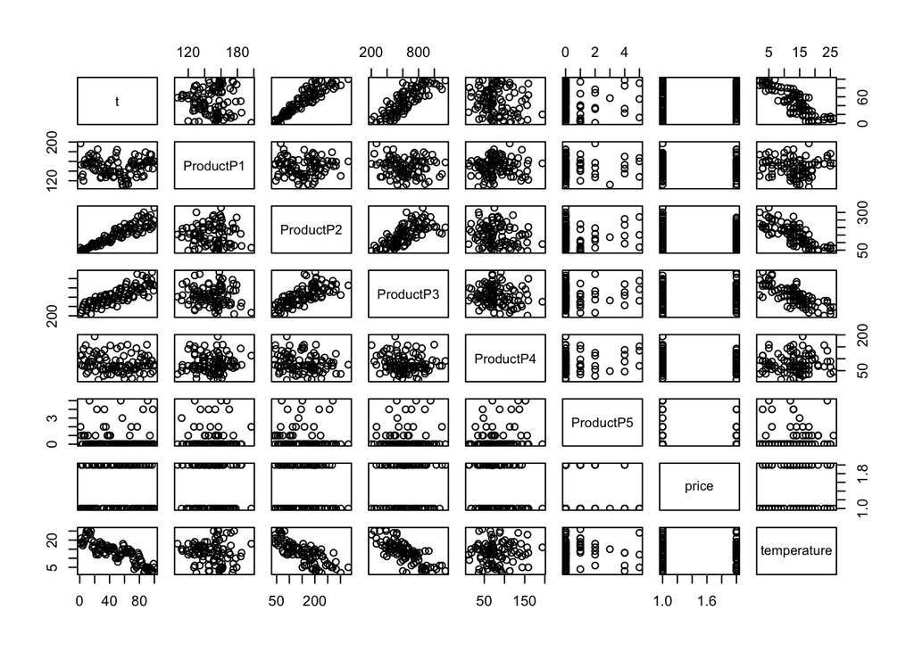

```r
plot(sales)
```

```r
cor(sales)
```

```
##                       t    ProductP1    ProductP2   ProductP3   ProductP4
## t            1.00000000 -0.016413977  0.915259699  0.83496406 -0.14710367
## ProductP1   -0.01641398  1.000000000  0.000055133 -0.08785101  0.05311842
## ProductP2    0.91525970  0.000055133  1.000000000  0.71628722 -0.18261873
## ProductP3    0.83496406 -0.087851008  0.716287218  1.00000000 -0.13560561
## ProductP4   -0.14710367  0.053118425 -0.182618730 -0.13560561  1.00000000
## ProductP5   -0.02769418  0.019914646 -0.041973650  0.04646901  0.16319303
## price       -0.01631148 -0.107463737 -0.043627500  0.05337200 -0.19197061
## temperature -0.86136844 -0.087900613 -0.777504896 -0.77422777  0.04525551
##               ProductP5       price temperature
## t           -0.02769418 -0.01631148 -0.86136844
## ProductP1    0.01991465 -0.10746374 -0.08790061
## ProductP2   -0.04197365 -0.04362750 -0.77750490
## ProductP3    0.04646901  0.05337200 -0.77422777
## ProductP4    0.16319303 -0.19197061  0.04525551
## ProductP5    1.00000000 -0.11253179 -0.01546351
## price       -0.11253179  1.00000000  0.00701284
## temperature -0.01546351  0.00701284  1.00000000
```

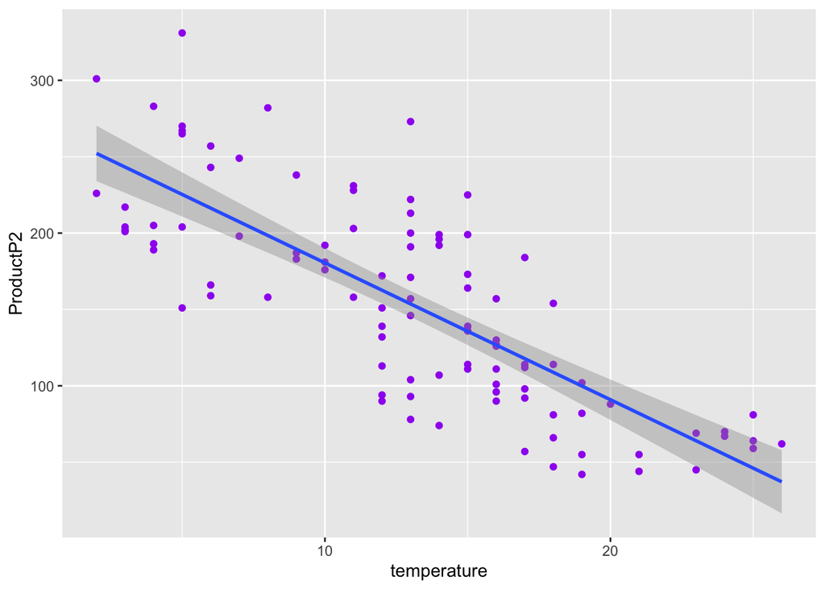

```r
ggplot(sales,aes(x=temperature,y=ProductP2))+geom_point(color="purple")+geom_smooth(method="lm")
```

The data is the time-series, consists of the sales of 5 products and temperature. As I conducted the correlation analysis, product 2 and the temperature had the highest correlation, so I decided to take temperature as a independent variable, which affects the sales of product2.

## 2. Perform regression

```r
model = lm(ProductP2~temperature,data=sales)
```

## 3. Perform Model Acceptance Steps and show the interpretation of the model output

```r
summary(model)
```

```
##
## Call:
## lm(formula = ProductP2 ~ temperature, data = sales)
##
## Residuals:
##    Min     1Q Median     3Q    Max
## -75.62 -30.62  -2.68  35.50 119.38
##
## Coefficients:
##             Estimate Std. Error t value Pr(>|t|)
## (Intercept)  270.095     10.460   25.82   <2e-16 ***
## temperature   -8.960      0.732  -12.24   <2e-16 ***
## ---
## Signif. codes:  0 '***' 0.001 '**' 0.01 '*' 0.05 '.' 0.1 ' ' 1
##
## Residual standard error: 43.09 on 98 degrees of freedom
## Multiple R-squared:  0.6045, Adjusted R-squared:  0.6005
## F-statistic: 149.8 on 1 and 98 DF,  p-value: < 2.2e-16
```

- Adjusted R squared is 0.6005, meaning that 60% of variation in the dependent variable(sales of P2) can be explained by this independent variable(temperature). Usually it means that the model is explaining the data well when the R squared is close to 1. So this model is considered meaningful.
- t value and p value : t value is -12.24 and p value is less than 2e-16. If we actually do calculate the critical value with the formula qt(.95,98), it’s 1.66, and the t value is far less than this. Also, as the p value is much smaller than 0.05, this model can be meaningful.
- F statistic : 149.8 with p value of less than 2.2e-16. If we calculate critical F value with the formula qf(.95,1,98), it’s 3.93 and the F statistics is much larger than this. Also, p value of it is much smaller than 0.05. All of these mean that this model can be meaningful.

## 4. Perform Residual Analysis and explain the insights

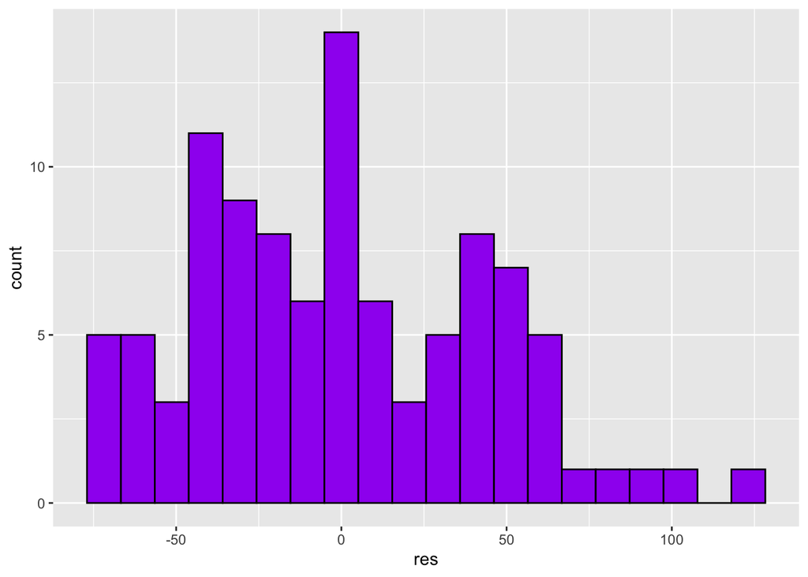

```r
#1. Normality
salesres = data.table('res'=model$residuals)
ggplot(salesres,aes(x=res))+geom_histogram(bins=20,fill="purple",color="black")
```

The histogram shows the residuals are not normally distributed.

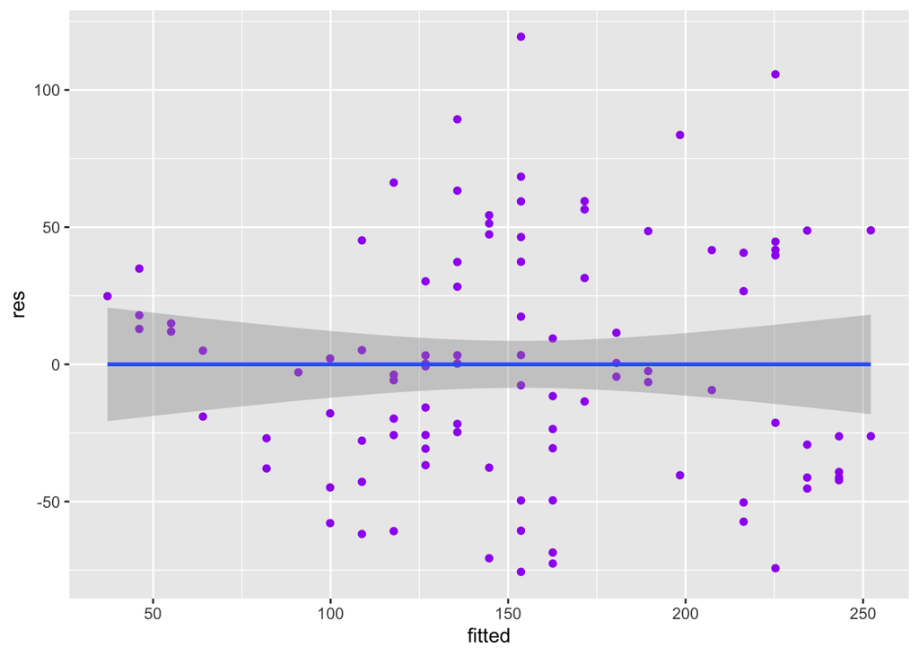

```r
#2. Equal Variance
salesres[,fitted:=model$fitted.values]
ggplot(salesres,aes(x=fitted,y=res))+geom_point(color="purple")+geom_smooth(method="lm")
```

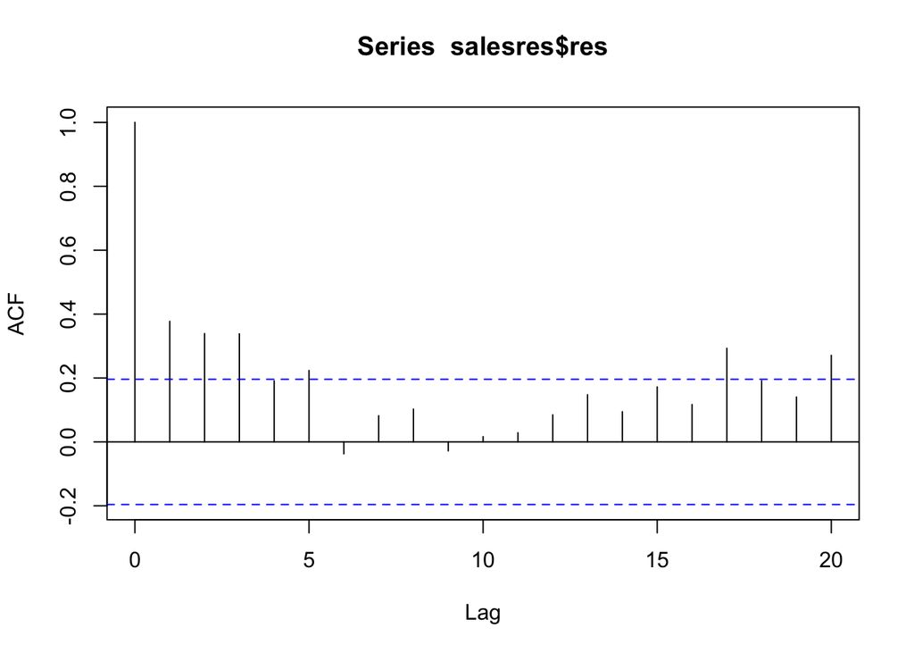

```r
acf(salesres$res)
```